# Lab 8: Cannabis Types

Author

Lily

**GitHub Repository**: https://github.com/lilysteinberg/GSB-544---Computing-and-ML/tree/main/Week%208

# Part 0: Preparation

This hidden code loads in the necessary packages.

```python
# packages
import numpy as np
import pandas as pd
from sklearn.pipeline import Pipeline
from sklearn.compose import ColumnTransformer
from sklearn.preprocessing import StandardScaler
from sklearn.discriminant_analysis import LinearDiscriminantAnalysis, QuadraticDiscriminantAnalysis
from sklearn.svm import SVC
from sklearn.tree import DecisionTreeClassifier, plot_tree
from sklearn.neighbors import KNeighborsClassifier
from sklearn.linear_model import LogisticRegression
from sklearn.metrics import r2_score, mean_squared_error, classification_report, confusion_matrix, ConfusionMatrixDisplay, RocCurveDisplay, roc_auc_score
from sklearn.model_selection import GridSearchCV, cross_val_score, StratifiedKFold, cross_val_predict
import matplotlib.pyplot as plt
```

This hidden code imports the data.

```python
# data
weed = pd.read_csv("cannabis_full.csv")
```

# Part 1: Binary Classification

```python
# limit dataset to indica and sativa
weed_limited = weed[(weed["Type"] == "indica") | (weed["Type"] == "sativa")]

# adjust data to work with models
weed_limited = weed_limited.drop(["Strain", "Effects", "Flavor"], axis=1)
weed_limited = weed_limited * 1
weed_limited = weed_limited.dropna() # count is now 1,118 (was 1,139)

# define X and y
X = weed_limited.drop(columns = ["Type"])
y = weed_limited['Type']
```

I will be using F1 scores as the metric for model selection. It combines precision and recall, and like ROC AUC, it is less misleading than accuracy. Importantly, it worked better for the models built in Part 2, and since those will be compared against the models also built in Part 1, I will use it throughout.

**Q1: LDA**

Find and fit the best model

```python
# make pipeline
lda_pipeline = Pipeline(
  [("lda", LinearDiscriminantAnalysis())]
)

# fit
lda_fitted = lda_pipeline.fit(X, y)
```

Cross-validated F1 score

```python
# create empty list of F1 score
f1_compare_p1 = []

# cross-validation to estimate F1 score
scores = cross_val_score(lda_pipeline,
                         X=X,
                         y=y,
                         scoring="f1_macro",
                         cv=5)

# add to list
f1_compare_p1.append(scores.mean())

# report score here
scores.mean()
```

```
np.float64(0.8299685165213692)
```

Confusion Matrix

```
[[623  64]
 [112 319]]
```

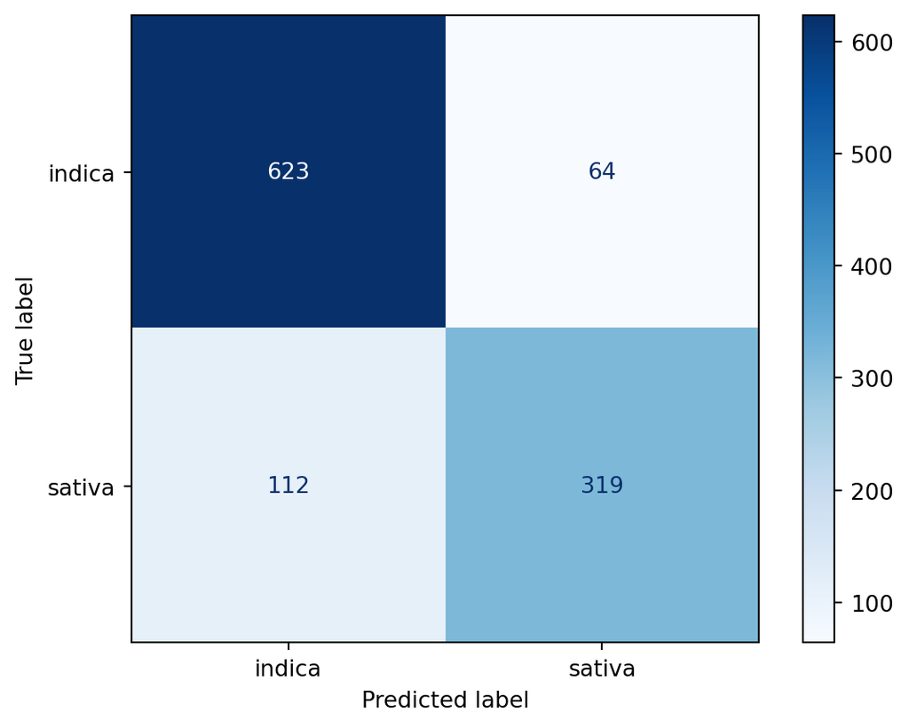

```python
# get predictions
y_pred = cross_val_predict(lda_pipeline, X, y, cv=5)

# confusion matrix
print(confusion_matrix(y, y_pred))

# visualize confusion matrix
ConfusionMatrixDisplay.from_predictions(
                                      y,
                                      y_pred,
                                      cmap = plt.cm.Blues)
```

**Q2: QDA**

Find and fit the best model (tune QDA’s reg_param hyperparameter because there is a warning about collinearity otherwise).

```python
# make pipeline for tuning
qda_pipeline = Pipeline(
  [("qda", QuadraticDiscriminantAnalysis())]
)

tuning = {'qda__reg_param': np.arange(0, 1, 0.1)}

gscv = GridSearchCV(qda_pipeline, param_grid=tuning, cv = 5, scoring='f1_macro', n_jobs=-1)

# feed in data
gscv_fitted = gscv.fit(X, y)
gscv_fitted.cv_results_

# view results
df_cv_results_ = pd.DataFrame(gscv_fitted.cv_results_)
df_cv_results_.sort_values(by = "rank_test_score", ascending = True)
```

|  | mean_fit_time | std_fit_time | mean_score_time | std_score_time | param_qda__reg_param | params | split0_test_score | split1_test_score | split2_test_score | split3_test_score | split4_test_score | mean_test_score | std_test_score | rank_test_score |
| --- | --- | --- | --- | --- | --- | --- | --- | --- | --- | --- | --- | --- | --- | --- |
| 1 | 0.039043 | 0.003417 | 0.009155 | 0.001284 | 0.1 | {'qda__reg_param': 0.1} | 0.834484 | 0.851290 | 0.825026 | 0.867510 | 0.849222 | 0.845506 | 0.014645 | 1 |
| 2 | 0.049963 | 0.007988 | 0.010191 | 0.001311 | 0.2 | {'qda__reg_param': 0.2} | 0.838095 | 0.839133 | 0.825026 | 0.847911 | 0.842800 | 0.838593 | 0.007604 | 2 |
| 3 | 0.021406 | 0.015264 | 0.009217 | 0.000920 | 0.3 | {'qda__reg_param': 0.30000000000000004} | 0.839133 | 0.820768 | 0.824224 | 0.837811 | 0.831662 | 0.830720 | 0.007255 | 3 |
| 4 | 0.013161 | 0.000627 | 0.008161 | 0.000849 | 0.4 | {'qda__reg_param': 0.4} | 0.836225 | 0.820768 | 0.818166 | 0.832405 | 0.840469 | 0.829607 | 0.008702 | 4 |
| 5 | 0.012479 | 0.000979 | 0.009778 | 0.001266 | 0.5 | {'qda__reg_param': 0.5} | 0.802563 | 0.819597 | 0.822508 | 0.814772 | 0.824563 | 0.816800 | 0.007842 | 5 |
| 6 | 0.011752 | 0.000389 | 0.009244 | 0.000886 | 0.6 | {'qda__reg_param': 0.6000000000000001} | 0.806949 | 0.806949 | 0.826864 | 0.812277 | 0.824563 | 0.815520 | 0.008578 | 6 |
| 7 | 0.012590 | 0.001183 | 0.008171 | 0.000772 | 0.7 | {'qda__reg_param': 0.7000000000000001} | 0.801161 | 0.806949 | 0.818592 | 0.800733 | 0.819188 | 0.809325 | 0.008115 | 7 |
| 8 | 0.012838 | 0.001380 | 0.007662 | 0.000604 | 0.8 | {'qda__reg_param': 0.8} | 0.801161 | 0.795322 | 0.818592 | 0.794886 | 0.822546 | 0.806501 | 0.011765 | 8 |
| 9 | 0.011146 | 0.001481 | 0.006072 | 0.000366 | 0.9 | {'qda__reg_param': 0.9} | 0.798184 | 0.783485 | 0.806447 | 0.799280 | 0.822546 | 0.801989 | 0.012702 | 9 |
| 0 | 0.034838 | 0.006304 | 0.007953 | 0.001805 | 0.0 | {'qda__reg_param': 0.0} | 0.393782 | 0.316564 | 0.406944 | 0.307774 | 0.317763 | 0.348565 | 0.042637 | 10 |

```python
# make optimal pipeline
qda_best_pipeline = Pipeline(
  [("qda", QuadraticDiscriminantAnalysis(reg_param = 0.2))]
).set_output(transform="pandas")

# fit
qda_best_pipeline_fitted = qda_best_pipeline.fit(X, y)
```

Cross-validated F1 score

```python
# cross-validation to estimate f1
scores = cross_val_score(qda_best_pipeline,
                         X=X,
                         y=y,
                         scoring="f1_macro",
                         cv=5)

# add to list
f1_compare_p1.append(scores.mean())

# report score here
scores.mean()
```

```
np.float64(0.8385931009642296)
```

Confusion Matrix

```
[[615  72]
 [ 97 334]]
```

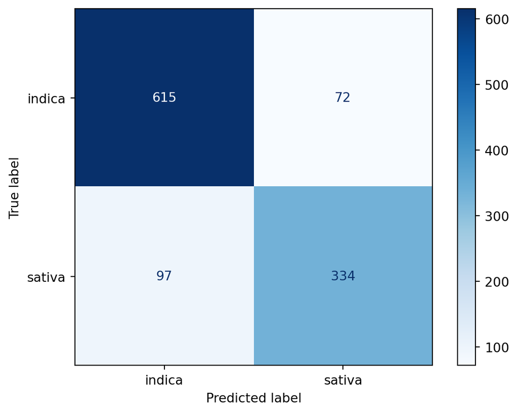

```python
# get predictions
y_pred = cross_val_predict(qda_best_pipeline, X, y, cv=5)

# confusion matrix
print(confusion_matrix(y, y_pred))

# visualize confusion matrix
ConfusionMatrixDisplay.from_predictions(
                                      y,
                                      y_pred,
                                      cmap = plt.cm.Blues)
```

**Q3: SVC**

Find and fit the best model

```python
# make pipeline for tuning
svc_pipeline = Pipeline(
  [("svc", SVC(kernel="linear", probability=True))]
)

param_grid = {'svc__C': [0.01, 0.1, 1, 10, 100]}

svc_pipeline_grid = GridSearchCV(svc_pipeline, param_grid, cv=5)
svc_pipeline_grid.fit(X, y)

# Best fitted pipeline & the SVC inside it
svc_pipeline_best = svc_pipeline_grid.best_estimator_
svc_model_best = svc_pipeline_best.named_steps["svc"]

# fit
svc_fitted = svc_pipeline_best.fit(X, y)
```

Cross-validated F1 score

```python
# cross-validation to estimate f1
scores = cross_val_score(svc_pipeline_best,
                         X=X,
                         y=y,
                         scoring="f1_macro",
                         cv=5)

# add to list
f1_compare_p1.append(scores.mean())

# report score here
scores.mean()
```

```
np.float64(0.8400849513852038)
```

Confusion Matrix

```
[[630  57]
 [108 323]]
```

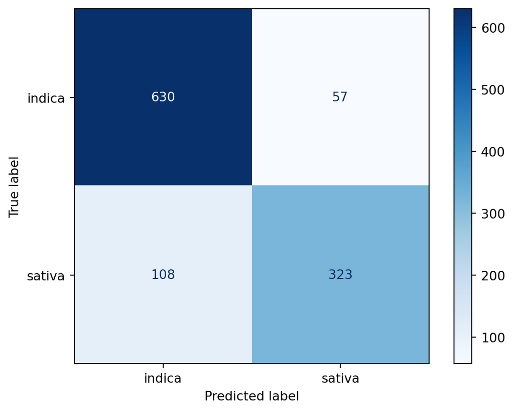

```python
# get predictions
y_pred = cross_val_predict(svc_pipeline_best, X, y, cv=5)

# confusion matrix
print(confusion_matrix(y, y_pred))

# visualize confusion matrix
ConfusionMatrixDisplay.from_predictions(
                                      y,
                                      y_pred,
                                      cmap = plt.cm.Blues)
```

**Q4: SVM**

Find and fit the best model

```python
# make pipeline for tuning
svm_pipeline = Pipeline(
  [("svm", SVC())]
)

param_grid = {
    'svm__C': [0.1, 1, 10, 100, 1000],
    'svm__gamma': [1, 0.1, 0.01, 0.001, 0.0001],
    'svm__kernel': ['rbf', 'poly']
    }

svm_pipeline_grid = GridSearchCV(svm_pipeline, param_grid, cv=5)
svm_pipeline_grid.fit(X, y)

# Best fitted pipeline & the SVM inside it
svm_pipeline_best = svm_pipeline_grid.best_estimator_
svm_model_best = svm_pipeline_best.named_steps["svm"]

# fit
svm_fitted = svc_pipeline_best.fit(X, y)
```

Cross-validated F1 score

```python
# cross-validation to estimate f1
scores = cross_val_score(svm_pipeline_best,
                         X=X,
                         y=y,
                         scoring="f1_macro",
                         cv=5)

# add to list
f1_compare_p1.append(scores.mean())

# report score here
scores.mean()
```

```
np.float64(0.8470624953174823)
```

Confusion Matrix

```
[[627  60]
 [ 99 332]]
```

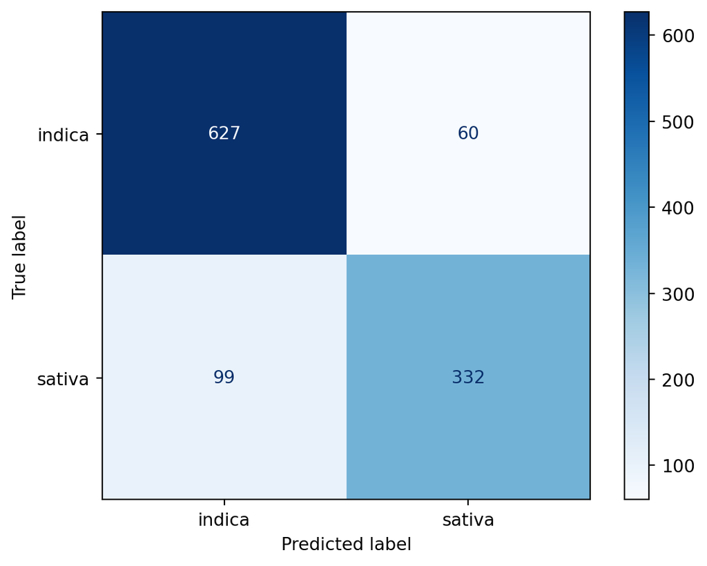

```python
# get predictions
y_pred = cross_val_predict(svm_pipeline_best, X, y, cv=5)

# confusion matrix
print(confusion_matrix(y, y_pred))

# visualize confusion matrix
ConfusionMatrixDisplay.from_predictions(
                                      y,
                                      y_pred,
                                      cmap = plt.cm.Blues)
```

**Model Performance Comparison**

```python
# create dataframe for comparing F1 scores
f1_compare_p1_df = pd.DataFrame({
    "model": ["LDA", "QDA", "SVC", "SVM"],
    "F1 scores": f1_compare_p1
})

f1_compare_p1_df.sort_values(by = "F1 scores", ascending = False)
```

|  | model | F1 scores |
| --- | --- | --- |
| 3 | SVM | 0.847062 |
| 2 | SVC | 0.840085 |
| 1 | QDA | 0.838593 |
| 0 | LDA | 0.829969 |

The SVM model performed the best, according to F1 score.

# Part Two: Natural Mulitclass

```python
# adjust data
weed = weed.drop(columns = ["Strain", "Effects", "Flavor"])
weed = weed * 1
weed = weed.dropna()

# assign y categories to numbers
label_map = {'indica': 1, 'sativa': 2, 'hybrid': 3}
weed['Type'] = weed["Type"].map(label_map)

# define X and y
X = weed.drop(columns = ["Type"])
y = weed['Type']
```

**Decision Tree**

Find and fit the best model

```python
# make pipeline for decision tree tuning
dt_pipeline = Pipeline(
    [
     ("dt", DecisionTreeClassifier())
    ],
).set_output(transform="pandas")

tuning = {
    'dt__ccp_alpha': np.arange(0, 1, 0.1),
    'dt__max_depth': np.arange(1,10, 1)
}

gscv = GridSearchCV(dt_pipeline, param_grid=tuning, cv = 5, scoring='f1_macro')

# feed in data
gscv_fitted = gscv.fit(X, y)
gscv_fitted.cv_results_

# view results
df_cv_results_ = pd.DataFrame(gscv_fitted.cv_results_)
df_cv_results_.sort_values(by = "rank_test_score", ascending = True)
```

|  | mean_fit_time | std_fit_time | mean_score_time | std_score_time | param_dt__ccp_alpha | param_dt__max_depth | params | split0_test_score | split1_test_score | split2_test_score | split3_test_score | split4_test_score | mean_test_score | std_test_score | rank_test_score |
| --- | --- | --- | --- | --- | --- | --- | --- | --- | --- | --- | --- | --- | --- | --- | --- |
| 2 | 0.003941 | 0.000078 | 0.002750 | 0.000091 | 0.0 | 3 | {'dt__ccp_alpha': 0.0, 'dt__max_depth': 3} | 0.549799 | 0.584236 | 0.580973 | 0.584739 | 0.618031 | 0.583556 | 0.021617 | 1 |
| 4 | 0.005675 | 0.000314 | 0.003116 | 0.000479 | 0.0 | 5 | {'dt__ccp_alpha': 0.0, 'dt__max_depth': 5} | 0.540504 | 0.574061 | 0.576717 | 0.588967 | 0.584771 | 0.573004 | 0.017114 | 2 |
| 5 | 0.006065 | 0.000526 | 0.002902 | 0.000228 | 0.0 | 6 | {'dt__ccp_alpha': 0.0, 'dt__max_depth': 6} | 0.537508 | 0.555697 | 0.591960 | 0.589596 | 0.577739 | 0.570500 | 0.020905 | 3 |
| 3 | 0.004489 | 0.000102 | 0.002855 | 0.000177 | 0.0 | 4 | {'dt__ccp_alpha': 0.0, 'dt__max_depth': 4} | 0.511396 | 0.569268 | 0.576891 | 0.599526 | 0.545446 | 0.560506 | 0.030021 | 4 |
| 7 | 0.007605 | 0.000691 | 0.003231 | 0.000722 | 0.0 | 8 | {'dt__ccp_alpha': 0.0, 'dt__max_depth': 8} | 0.523369 | 0.559268 | 0.564799 | 0.577838 | 0.564043 | 0.557864 | 0.018314 | 5 |
| ... | ... | ... | ... | ... | ... | ... | ... | ... | ... | ... | ... | ... | ... | ... | ... |
| 85 | 0.005382 | 0.000148 | 0.003075 | 0.000315 | 0.9 | 5 | {'dt__ccp_alpha': 0.9, 'dt__max_depth': 5} | 0.226991 | 0.226991 | 0.226361 | 0.226361 | 0.226361 | 0.226613 | 0.000309 | 10 |
| 86 | 0.005941 | 0.000144 | 0.002783 | 0.000098 | 0.9 | 6 | {'dt__ccp_alpha': 0.9, 'dt__max_depth': 6} | 0.226991 | 0.226991 | 0.226361 | 0.226361 | 0.226361 | 0.226613 | 0.000309 | 10 |
| 87 | 0.007402 | 0.000482 | 0.003199 | 0.000489 | 0.9 | 7 | {'dt__ccp_alpha': 0.9, 'dt__max_depth': 7} | 0.226991 | 0.226991 | 0.226361 | 0.226361 | 0.226361 | 0.226613 | 0.000309 | 10 |
| 88 | 0.009182 | 0.001557 | 0.003764 | 0.001237 | 0.9 | 8 | {'dt__ccp_alpha': 0.9, 'dt__max_depth': 8} | 0.226991 | 0.226991 | 0.226361 | 0.226361 | 0.226361 | 0.226613 | 0.000309 | 10 |
| 89 | 0.008647 | 0.000960 | 0.003650 | 0.000668 | 0.9 | 9 | {'dt__ccp_alpha': 0.9, 'dt__max_depth': 9} | 0.226991 | 0.226991 | 0.226361 | 0.226361 | 0.226361 | 0.226613 | 0.000309 | 10 |

90 rows × 15 columns

```python
dt_best_pipeline = Pipeline(
    [
     ("dt", DecisionTreeClassifier(ccp_alpha=0.0, max_depth=3))
    ],
).set_output(transform="pandas")

# fit
dt_best_pipeline_fitted = dt_best_pipeline.fit(X, y)
```

Plot

```
[Text(0.5, 0.875, 'Focused <= 0.5\ngini = 0.611\nsamples = 2305\nvalue = [687, 431, 1187]\nclass = hybrid'),
```

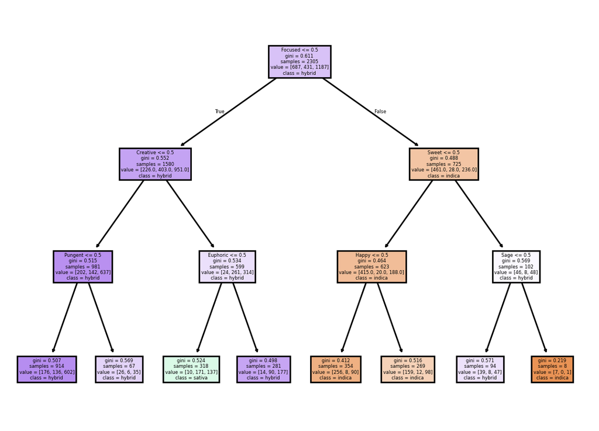

```python
# get list of feature names
feature_names = weed.columns

# plot tree
plot_tree(dt_best_pipeline.named_steps["dt"], feature_names = feature_names, class_names = ["indica", "sativa", "hybrid"], filled=True)
```

Cross-validated F1 Score

```python
# create empty list of f1_macro scores
f1_compare = []

# cross-validation to estimate f1_macro
scores = cross_val_score(dt_best_pipeline,
                         X=X,
                         y=y,
                         scoring="f1_macro",
                         cv=5)

# add to list
f1_compare.append(scores.mean())

# report score here
scores.mean()
```

```
np.float64(0.5835558310799394)
```

Confusion Matrix

```
[[433  11 243]
 [ 24 171 236]
 [220 138 829]]
```

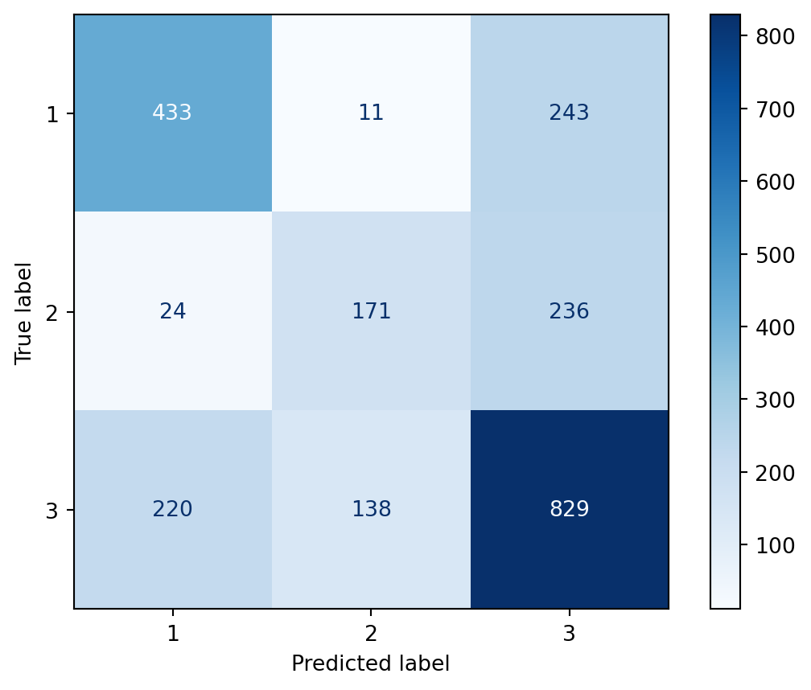

```python
# get predictions
y_pred = cross_val_predict(dt_best_pipeline, X, y, cv=5)

# confusion matrix
print(confusion_matrix(y, y_pred))

# visualize confusion matrix
ConfusionMatrixDisplay.from_predictions(
                                      y,
                                      y_pred,
                                      cmap = plt.cm.Blues)
```

**Q2: LDA**

Find and fit the best model

```python
# make pipeline for LDA multiclass
ldam_pipeline = Pipeline(
  [
  ("lda", LinearDiscriminantAnalysis())]
)

# fit
ldam_fitted = ldam_pipeline.fit(X, y)
```

Cross-validated F1 Score

```python
# cross-validation to estimate f1_macro
scores = cross_val_score(ldam_pipeline,
                         X=X,
                         y=y,
                         scoring="f1_macro",
                         cv=5)

# add to list
f1_compare.append(scores.mean())

# report score here
scores.mean()
```

```
np.float64(0.5939249916749908)
```

Confusion Matrix

```
[[455  12 220]
 [ 23 178 230]
 [224 146 817]]
```

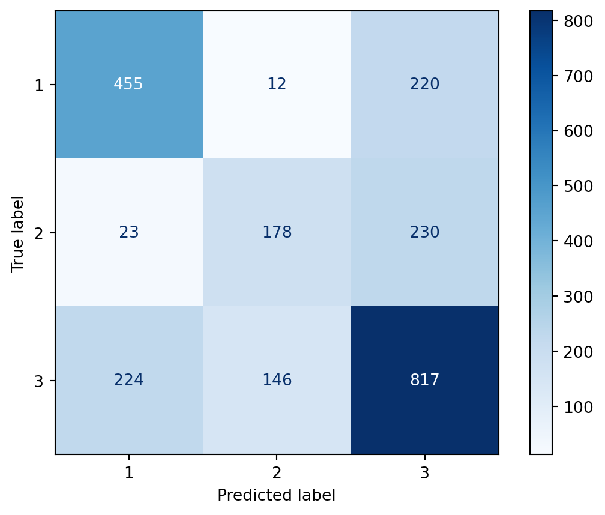

```python
# get predictions
y_pred = cross_val_predict(ldam_pipeline, X, y, cv=5)

# confusion matrix
print(confusion_matrix(y, y_pred))

# visualize confusion matrix
ConfusionMatrixDisplay.from_predictions(
                                      y,
                                      y_pred,
                                      cmap = plt.cm.Blues)
```

**Q2: QDA**

Find and fit the best model

```python
# make pipeline for tuning
qdam_pipeline = Pipeline(
  [("qda", QuadraticDiscriminantAnalysis())]
)

tuning = {'qda__reg_param': np.arange(0, 1, 0.1)}

gscv = GridSearchCV(qda_pipeline, param_grid=tuning, cv = 5, scoring='f1_macro')

# feed in data
gscv_fitted = gscv.fit(X, y)
gscv_fitted.cv_results_

# view results
df_cv_results_ = pd.DataFrame(gscv_fitted.cv_results_)
df_cv_results_.sort_values(by = "rank_test_score", ascending = True)
```

[output not shown]

|  | mean_fit_time | std_fit_time | mean_score_time | std_score_time | param_qda__reg_param | params | split0_test_score | split1_test_score | split2_test_score | split3_test_score | split4_test_score | mean_test_score | std_test_score | rank_test_score |
| --- | --- | --- | --- | --- | --- | --- | --- | --- | --- | --- | --- | --- | --- | --- |
| 1 | 0.015140 | 0.002041 | 0.004104 | 0.000465 | 0.1 | {'qda__reg_param': 0.1} | 0.539351 | 0.593892 | 0.593374 | 0.555943 | 0.606325 | 0.577777 | 0.025578 | 1 |
| 2 | 0.015559 | 0.001771 | 0.004027 | 0.000237 | 0.2 | {'qda__reg_param': 0.2} | 0.507663 | 0.576079 | 0.588646 | 0.574265 | 0.591337 | 0.567598 | 0.030709 | 2 |
| 3 | 0.013691 | 0.001475 | 0.003934 | 0.000348 | 0.3 | {'qda__reg_param': 0.30000000000000004} | 0.480798 | 0.573370 | 0.571057 | 0.566806 | 0.565591 | 0.551524 | 0.035475 | 3 |
| 4 | 0.016565 | 0.006952 | 0.004038 | 0.000337 | 0.4 | {'qda__reg_param': 0.4} | 0.473140 | 0.517491 | 0.512056 | 0.515440 | 0.525458 | 0.508717 | 0.018326 | 4 |
| 5 | 0.011746 | 0.002015 | 0.003868 | 0.000158 | 0.5 | {'qda__reg_param': 0.5} | 0.438767 | 0.489959 | 0.461046 | 0.474148 | 0.504231 | 0.473630 | 0.022703 | 5 |
| 6 | 0.009756 | 0.000533 | 0.003780 | 0.000235 | 0.6 | {'qda__reg_param': 0.6000000000000001} | 0.425258 | 0.458124 | 0.454603 | 0.448086 | 0.457224 | 0.448659 | 0.012217 | 6 |
| 7 | 0.020803 | 0.008448 | 0.004696 | 0.000681 | 0.7 | {'qda__reg_param': 0.7000000000000001} | 0.408533 | 0.447734 | 0.417340 | 0.412460 | 0.425813 | 0.422376 | 0.013929 | 7 |
| 8 | 0.009705 | 0.000379 | 0.004092 | 0.000733 | 0.8 | {'qda__reg_param': 0.8} | 0.393253 | 0.422714 | 0.382756 | 0.362682 | 0.370424 | 0.386366 | 0.020961 | 8 |
| 9 | 0.015625 | 0.008998 | 0.003715 | 0.000065 | 0.9 | {'qda__reg_param': 0.9} | 0.391879 | 0.382851 | 0.357685 | 0.337778 | 0.347571 | 0.363553 | 0.020635 | 9 |
| 0 | 0.030432 | 0.032403 | 0.003877 | 0.000088 | 0.0 | {'qda__reg_param': 0.0} | 0.183824 | 0.128340 | 0.187440 | 0.129946 | 0.133243 | 0.152559 | 0.027075 | 10 |

```python
# make optimal pipeline
qdam_best_pipeline = Pipeline(
  [("qda", QuadraticDiscriminantAnalysis(reg_param = 0.1))]
).set_output(transform="pandas")

# fit
qdam_best_pipeline_fitted = qdam_best_pipeline.fit(X, y)
```

Cross-validated F1 Score

```python
# cross-validation to estimate f1_macro
scores = cross_val_score(qdam_best_pipeline,
                         X=X,
                         y=y,
                         scoring="f1_macro",
                         cv=5)

# add to list
f1_compare.append(scores.mean())

# report score here
scores.mean()
```

```
np.float64(0.5777768413774191)
```

Confusion Matrix

```
[[509  16 162]
 [ 30 201 200]
 [349 174 664]]
```

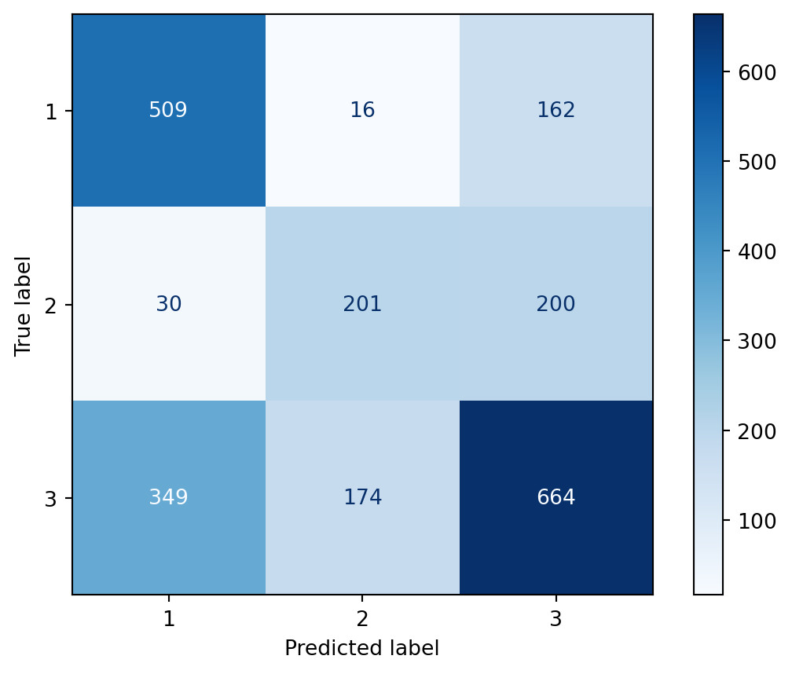

```python
# get predictions
y_pred = cross_val_predict(qdam_best_pipeline, X, y, cv=5)

# confusion matrix
print(confusion_matrix(y, y_pred))

# visualize confusion matrix
ConfusionMatrixDisplay.from_predictions(
                                      y,
                                      y_pred,
                                      cmap = plt.cm.Blues)
```

**Q2: KNN**

Find and fit the best model

```python
# make pipeline for knn tuning
knn_pipeline = Pipeline(
    [
     ("knn", KNeighborsClassifier())
    ],
).set_output(transform="pandas")

neighbors = {'knn__n_neighbors': np.arange(1, 11, 1)}

gscv = GridSearchCV(knn_pipeline, param_grid=neighbors, cv = 5, scoring='f1_macro')

# feed in data
gscv_fitted = gscv.fit(X, y)
gscv_fitted.cv_results_

# view results
df_cv_results_ = pd.DataFrame(gscv_fitted.cv_results_)
df_cv_results_.sort_values(by = "rank_test_score", ascending = True)
```

[output not shown]

|  | mean_fit_time | std_fit_time | mean_score_time | std_score_time | param_knn__n_neighbors | params | split0_test_score | split1_test_score | split2_test_score | split3_test_score | split4_test_score | mean_test_score | std_test_score | rank_test_score |
| --- | --- | --- | --- | --- | --- | --- | --- | --- | --- | --- | --- | --- | --- | --- |
| 9 | 0.002752 | 0.000209 | 0.035085 | 0.001391 | 10 | {'knn__n_neighbors': 10} | 0.501909 | 0.570703 | 0.575099 | 0.547093 | 0.559682 | 0.550897 | 0.026342 | 1 |
| 5 | 0.003172 | 0.000330 | 0.033255 | 0.001014 | 6 | {'knn__n_neighbors': 6} | 0.552286 | 0.548972 | 0.547947 | 0.536622 | 0.560083 | 0.549182 | 0.007587 | 2 |
| 7 | 0.002518 | 0.000014 | 0.031453 | 0.000917 | 8 | {'knn__n_neighbors': 8} | 0.519531 | 0.541203 | 0.560122 | 0.524059 | 0.577216 | 0.544426 | 0.021756 | 3 |
| 3 | 0.002843 | 0.000361 | 0.032083 | 0.000834 | 4 | {'knn__n_neighbors': 4} | 0.528805 | 0.542939 | 0.537137 | 0.533643 | 0.557464 | 0.539997 | 0.009875 | 4 |
| 6 | 0.002932 | 0.000324 | 0.032583 | 0.000728 | 7 | {'knn__n_neighbors': 7} | 0.528673 | 0.519654 | 0.544346 | 0.520158 | 0.549565 | 0.532479 | 0.012358 | 5 |
| 8 | 0.002544 | 0.000086 | 0.032498 | 0.001681 | 9 | {'knn__n_neighbors': 9} | 0.502210 | 0.520797 | 0.564162 | 0.504347 | 0.537807 | 0.525865 | 0.023054 | 6 |
| 4 | 0.002986 | 0.000225 | 0.033017 | 0.001461 | 5 | {'knn__n_neighbors': 5} | 0.514396 | 0.506918 | 0.529668 | 0.512504 | 0.515898 | 0.515877 | 0.007537 | 7 |
| 2 | 0.003562 | 0.000844 | 0.033547 | 0.000952 | 3 | {'knn__n_neighbors': 3} | 0.470257 | 0.483702 | 0.506163 | 0.473419 | 0.522646 | 0.491237 | 0.020118 | 8 |
| 1 | 0.002984 | 0.000236 | 0.032556 | 0.002255 | 2 | {'knn__n_neighbors': 2} | 0.472154 | 0.476475 | 0.470392 | 0.472696 | 0.523768 | 0.483097 | 0.020432 | 9 |
| 0 | 0.004607 | 0.000426 | 0.058602 | 0.032055 | 1 | {'knn__n_neighbors': 1} | 0.461405 | 0.450248 | 0.458548 | 0.503365 | 0.508678 | 0.476449 | 0.024481 | 10 |

```python
# make pipeline for neighbors = 10
knn_best_pipeline = Pipeline(
    [
     ("knn", KNeighborsClassifier(n_neighbors=10))
    ],
).set_output(transform="pandas")

# fit
knn_best_pipeline_fitted = knn_best_pipeline.fit(X, y)
```

Cross-validated F1 Score

```python
# cross-validation to estimate f1_macro
scores = cross_val_score(knn_best_pipeline,
                         X=X,
                         y=y,
                         scoring="f1_macro",
                         cv=5)

# add to list
f1_compare.append(scores.mean())

# report score here
scores.mean()
```

```
np.float64(0.5508971668750446)
```

Confusion Matrix

```
[[414   9 264]
 [ 29 155 247]
 [255 138 794]]
```

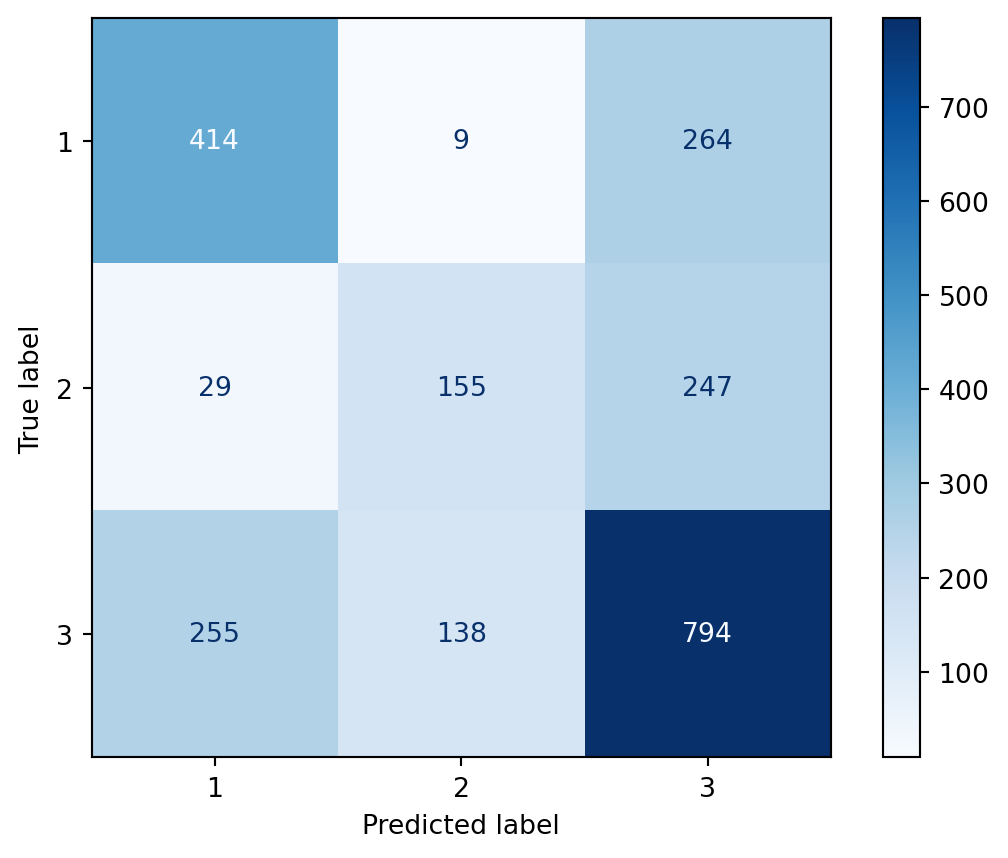

```python
# get predictions
y_pred = cross_val_predict(knn_best_pipeline, X, y, cv=5)

# confusion matrix
print(confusion_matrix(y, y_pred))

# visualize confusion matrix
ConfusionMatrixDisplay.from_predictions(
                                      y,
                                      y_pred,
                                      cmap = plt.cm.Blues)
```

**Model Performance Comparison**

```python
# create dataframe for comparing F1 macro values
f1_compare_df = pd.DataFrame({
    "model": ["Decision Tree", "LDA", "QDA", "KNN"],
    "F1 macro values": f1_compare
})

f1_compare_df.sort_values(by = "F1 macro values", ascending = False)
```

|  | model | F1 macro values |
| --- | --- | --- |
| 1 | LDA | 0.593925 |
| 0 | Decision Tree | 0.583556 |
| 2 | QDA | 0.577777 |
| 3 | KNN | 0.550897 |

**Q3: Compare and Interpret**

The models in Part 2, which involved multiclass classification, had lower f1 scores than the models in Part 1, which involved binary classification. This makes sense, since there were more ways for the models to predict incorrectly when there were more classes, so the models were more fallible.

The models were generally the worst at correctly classifying sativa (labeled as 2) compared to indica (labeled as 1) or hybrid (labeled as 3). The confusion matrices show that the hybrid category was most likely to be mixed up. This makes sense, since hybrid refers to a hybrid between indica and sativa, so it may be safe to assume they have properties that are more similar to those categories than indica and sativa have with each other.

# Part Three: Multiclass from Binary

**Q1: Build OvR for Logistic and SVC Models**

Fit a logistic regression for when “Type” = “indica” is 1, and is 0 for all others.

```python
# adjust data
weed["type_is_indica"] = (weed["Type"] == 1) * 1
y = weed["type_is_indica"]
```

```python
# make pipeline for logistic tuning
logistic_pipeline = Pipeline(
  [
   ("logistic", LogisticRegression(penalty = 'l1', max_iter=500)) #setting max iter reduces warnings
  ]
).set_output(transform="pandas")

# tune lasso penalty hyperparameter
# splitting up the L1 (lasso) penalty and the 'none' penalty like this reduce the warnings that occur because 'none' and 'C' do not match
param_grid = [
    # Case 1: L1 penalty (lasso)
    {
        'logistic__penalty': ['l1'],
        'logistic__C': [0.001, 0.01, 0.1, 1, 10, 100],
        'logistic__solver': ['liblinear', 'saga']
    },
    # Case 2: No penalty
    {
        'logistic__penalty': ['none'],
        'logistic__solver': ['lbfgs', 'saga']
    }
]

gscv = GridSearchCV(logistic_pipeline, param_grid=param_grid, cv = 5, scoring='f1_macro')

# feed in the data
gscv_fitted = gscv.fit(X, y)

# Best fitted pipeline & the logistic inside it
logistic_pipeline_best_indica = gscv.best_estimator_
logistic_model_best_indica = logistic_pipeline_best_indica.named_steps["logistic"]

# fit
logistic_model_best_indica_fitted = logistic_pipeline_best_indica.fit(X, y)

# cross-validation to estimate f1
mean_score = gscv_fitted.best_score_

# create empty list of f1 scores
f1_compare_OvR = []
# add to list
f1_compare_OvR.append(mean_score)

# report score here
mean_score
```

[output not shown]

[output cut: 26 more lines]

[output not shown]

```
np.float64(0.7529940006789648)
```

Fit a logistic regression for when “Type” = “sativa” is 1, and is 0 for all others.

```python
# adjust data
weed["type_is_sativa"] = (weed["Type"] == 2) * 1
y = weed["type_is_sativa"]
```

```python
# make pipeline for logistic tuning
logistic_pipeline = Pipeline(
  [
   ("logistic", LogisticRegression(penalty = 'l1', max_iter=500)) #setting max iter reduces warnings
  ]
).set_output(transform="pandas")

# tune lasso penalty hyperparameter
# splitting up the L1 (lasso) penalty and the 'none' penalty like this reduce the warnings that occur because 'none' and 'C' do not match
param_grid = [
    # Case 1: L1 penalty (lasso)
    {
        'logistic__penalty': ['l1'],
        'logistic__C': [0.001, 0.01, 0.1, 1, 10, 100],
        'logistic__solver': ['liblinear', 'saga']
    },
    # Case 2: No penalty
    {
        'logistic__penalty': ['none'],
        'logistic__solver': ['lbfgs', 'saga']
    }
]

gscv = GridSearchCV(logistic_pipeline, param_grid=param_grid, cv = 5, scoring='f1_macro')

# feed in the data
gscv_fitted = gscv.fit(X, y)

# Best fitted pipeline & the logistic inside it
logistic_pipeline_best_sativa = gscv.best_estimator_
logistic_model_best_sativa = logistic_pipeline_best_sativa.named_steps["logistic"]

# cross-validation to estimate f1
mean_score = gscv_fitted.best_score_

# add to list
f1_compare_OvR.append(mean_score)

# report score here
mean_score
```

[output not shown]

[output cut: 30 more lines]

[output not shown]

```
np.float64(0.6485881323483911)
```

Fit a logistic regression for when “Type” = “hybrid” is 1, and is 0 for all others.

```python
# adjust data
weed["type_is_hybrid"] = (weed["Type"] == 3) * 1
y = weed["type_is_hybrid"]
```

```python
# make pipeline for logistic tuning
logistic_pipeline = Pipeline(
  [
   ("logistic", LogisticRegression(penalty = 'l1', max_iter=500)) #setting max iter reduces warnings
  ]
).set_output(transform="pandas")

# tune lasso penalty hyperparameter
# splitting up the L1 (lasso) penalty and the 'none' penalty like this reduce the warnings that occur because 'none' and 'C' do not match
param_grid = [
    # Case 1: L1 penalty (lasso)
    {
        'logistic__penalty': ['l1'],
        'logistic__C': [0.001, 0.01, 0.1, 1, 10, 100],
        'logistic__solver': ['liblinear', 'saga']
    },
    # Case 2: No penalty
    {
        'logistic__penalty': ['none'],
        'logistic__solver': ['lbfgs', 'saga']
    }
]

gscv = GridSearchCV(logistic_pipeline, param_grid=param_grid, cv = 5, scoring='f1_macro')

# feed in the data
gscv_fitted = gscv.fit(X, y)

# Best fitted pipeline & the logistic inside it
logistic_pipeline_best_hybrid = gscv.best_estimator_
logistic_model_best_hybrid = logistic_pipeline_best_hybrid.named_steps["logistic"]

# cross-validation to estimate f1
mean_score = gscv_fitted.best_score_

# add to list
f1_compare_OvR.append(mean_score)

# report score here
mean_score
```

[output not shown]

[output cut: 30 more lines]

[output not shown]

```
np.float64(0.6169276957382465)
```

Repeat the OvR approach using SVC instead of logistic regression.

Fit SVC for when “Type” = “indica” is 1, and is 0 for all others.

```python
# set y
y = weed["type_is_indica"]
```

```python
# make pipeline for tuning
svc_pipeline = Pipeline(
  [("svc", SVC(kernel="linear", probability=True))]
)

param_grid = {'svc__C': [0.01, 0.1, 1, 10, 100]}

svc_pipeline_grid = GridSearchCV(svc_pipeline, param_grid, cv=5, scoring='f1_macro', n_jobs=-1)
svc_pipeline_grid.fit(X, y)

# Best fitted pipeline & the SVC inside it
svc_pipeline_best_indica = svc_pipeline_grid.best_estimator_
svc_model_best_indica = svc_pipeline_best_indica.named_steps["svc"]

# cross-validation to estimate f1
mean_score = svc_pipeline_grid.best_score_

# add to list
f1_compare_OvR.append(mean_score)

# report score here
mean_score
```

```
np.float64(0.750281577835873)
```

Fit SVC for when “Type” = “sativa” is 1, and is 0 for all others.

```python
# set y
y = weed["type_is_sativa"]
```

```python
# make pipeline for tuning
svc_pipeline = Pipeline(
  [("svc", SVC(kernel="linear", probability=True))]
)

param_grid = {'svc__C': [0.01, 0.1, 1, 10, 100]}

svc_pipeline_grid = GridSearchCV(svc_pipeline, param_grid, cv=5, scoring='f1_macro', n_jobs=-1)
svc_pipeline_grid.fit(X, y)

# Best fitted pipeline & the SVC inside it
svc_pipeline_best_sativa = svc_pipeline_grid.best_estimator_
svc_model_best_sativa = svc_pipeline_best_sativa.named_steps["svc"]

# cross-validation to estimate f1
mean_score = svc_pipeline_grid.best_score_

# add to list
f1_compare_OvR.append(mean_score)

# report score here
mean_score
```

```
np.float64(0.5763191470050215)
```

Fit SVC for when “Type” = “hybrid” is 1, and is 0 for all others.

```python
# set y
y = weed["type_is_hybrid"]
```

```python
# make pipeline for tuning
svc_pipeline = Pipeline(
  [("svc", SVC(kernel="linear", probability=False))]
)

param_grid = {'svc__C': [0.01, 0.1, 1, 10, 100]}

svc_pipeline_grid = GridSearchCV(svc_pipeline, param_grid, cv=5, scoring='f1_macro', n_jobs=-1)
svc_pipeline_grid.fit(X, y)

# Best fitted pipeline & the SVC inside it
svc_pipeline_best_hybrid = svc_pipeline_grid.best_estimator_
svc_model_best_hybrid = svc_pipeline_best_hybrid.named_steps["svc"]

# fit
svc_fitted_hybrid = svc_pipeline_best_hybrid.fit(X, y)

# cross-validation to estimate f1
mean_score = svc_pipeline_grid.best_score_

# add to list
f1_compare_OvR.append(mean_score)

# report score here
mean_score
```

```
np.float64(0.6093934976251951)
```

**Q2: Compare OvR for Logistic and SVC Models**

```python
# create dataframe for comparing F1 scores
f1_compare_OvR_df = pd.DataFrame({
    "model and target class": ["Logistic_indica", "Logistic_sativa", "Logistic_hybrid", "SVC_indica", "SVC_sativa", "SVC_hybrid"],
    "F1 scores": f1_compare_OvR
})

f1_compare_OvR_df.sort_values(by = "F1 scores", ascending = False)
```

|  | model and target class | F1 scores |
| --- | --- | --- |
| 0 | Logistic_indica | 0.752994 |
| 3 | SVC_indica | 0.750282 |
| 1 | Logistic_sativa | 0.648588 |
| 2 | Logistic_hybrid | 0.616928 |
| 5 | SVC_hybrid | 0.609393 |
| 4 | SVC_sativa | 0.576319 |

The logistic model using indica as the target class did the best job distinguishing the target category from the rest. The SVC model using sativa as the target class did the worst.

It makes intuitive sense that using sativa or indica as the target class would perform the best, since hybrid probably shares some qualities with both and therefore could be harder to distinguish. I found it surprising that the SVC model for the sativa class performed so badly, but there’s no way to see if SVC or logistic modeling will be better without trying them both.

**Q3: Build OvO for Logistic and SVC Models**

Fit logistic regression for when “Type” = “indica” is 1 and “Type” = “sativa” is 0.

```python
# adjust data
weed_12 = weed[(weed["Type"] == 1) | (weed["Type"] == 2)]
weed_12 = weed_12.drop(columns = ["type_is_indica", "type_is_sativa", "type_is_hybrid"])
# assign y categories to numbers
label_map = {1: 1, 2: 0}
weed_12['Type'] = weed_12["Type"].map(label_map)

# set X and y
X = weed_12.drop(columns = ["Type"])
y = weed_12["Type"]
```

```python
# make pipeline for logistic tuning
logistic_pipeline = Pipeline(
  [
   ("logistic", LogisticRegression(penalty = 'l1', max_iter=500)) #setting max iter reduces warnings
  ]
).set_output(transform="pandas")

# tune lasso penalty hyperparameter
# splitting up the L1 (lasso) penalty and the 'none' penalty like this reduce the warnings that occur because 'none' and 'C' do not match
param_grid = [
    # Case 1: L1 penalty (lasso)
    {
        'logistic__penalty': ['l1'],
        'logistic__C': [0.001, 0.01, 0.1, 1, 10, 100],
        'logistic__solver': ['liblinear', 'saga']
    },
    # Case 2: No penalty
    {
        'logistic__penalty': ['none'],
        'logistic__solver': ['lbfgs', 'saga']
    }
]

gscv = GridSearchCV(logistic_pipeline, param_grid=param_grid, cv = 5, scoring='f1_macro', n_jobs=-1)

# feed in the data
gscv_fitted = gscv.fit(X, y)

# Best fitted pipeline & the logistic inside it
logistic_pipeline_best_12 = gscv.best_estimator_
logistic_model_best_12 = logistic_pipeline_best_12.named_steps["logistic"]

# cross-validation to estimate f1
mean_score = gscv_fitted.best_score_

# create empty list of f1 scores
f1_compare_OvO = []
# add to list
f1_compare_OvO.append(mean_score)

# report score here
mean_score
```

[output not shown]

```
np.float64(0.8394032694784022)
```

Fit logistic regression for when “Type” = “indica” is 1 and “Type” = “hybrid” is 0.

```python
# adjust data
weed_13 = weed[(weed["Type"] == 1) | (weed["Type"] == 3)]
weed_13 = weed_13.drop(columns = ["type_is_indica", "type_is_sativa", "type_is_hybrid"])
# assign y categories to numbers
label_map = {1: 1, 3: 0}
weed_13['Type'] = weed_13["Type"].map(label_map)

# set X and y
X = weed_13.drop(columns = ["Type"])
y = weed_13["Type"]
```

```python
# make pipeline for logistic tuning
logistic_pipeline = Pipeline(
  [
   ("logistic", LogisticRegression(penalty = 'l1', max_iter=500)) #setting max iter reduces warnings
  ]
).set_output(transform="pandas")

# tune lasso penalty hyperparameter
# splitting up the L1 (lasso) penalty and the 'none' penalty like this reduce the warnings that occur because 'none' and 'C' do not match
param_grid = [
    # Case 1: L1 penalty (lasso)
    {
        'logistic__penalty': ['l1'],
        'logistic__C': [0.001, 0.01, 0.1, 1, 10, 100],
        'logistic__solver': ['liblinear', 'saga']
    },
    # Case 2: No penalty
    {
        'logistic__penalty': ['none'],
        'logistic__solver': ['lbfgs', 'saga']
    }
]

gscv = GridSearchCV(logistic_pipeline, param_grid=param_grid, cv = 5, scoring='f1_macro', n_jobs=-1)

# feed in the data
gscv_fitted = gscv.fit(X, y)

# Best fitted pipeline & the logistic inside it
logistic_pipeline_best_13 = gscv.best_estimator_
logistic_model_best_13 = logistic_pipeline_best_13.named_steps["logistic"]

# fit
logistic_model_best_13_fitted = logistic_pipeline_best_13.fit(X, y)

# cross-validation to estimate f1
mean_score = gscv_fitted.best_score_

# add to list
f1_compare_OvO.append(mean_score)

# report score here
mean_score
```

[output not shown]

[output cut: 52 more lines]

[output not shown]

```
np.float64(0.7367781586701081)
```

Fit logistic regression for when “Type” = “hybrid” is 1 and “Type” = “sativa” is 0.

```python
# adjust data
weed_23 = weed[(weed["Type"] == 2) | (weed["Type"] == 3)]
weed_23 = weed_23.drop(columns = ["type_is_indica", "type_is_sativa", "type_is_hybrid"])
# assign y categories to numbers
label_map = {3: 1, 2: 0}
weed_23['Type'] = weed_23["Type"].map(label_map)

# set X and y
X = weed_23.drop(columns = ["Type"])
y = weed_23["Type"]
```

```python
# make pipeline for logistic tuning
logistic_pipeline = Pipeline(
  [
   ("logistic", LogisticRegression(penalty = 'l1', max_iter=500)) #setting max iter reduces warnings
  ]
).set_output(transform="pandas")

# tune lasso penalty hyperparameter
# splitting up the L1 (lasso) penalty and the 'none' penalty like this reduce the warnings that occur because 'none' and 'C' do not match
param_grid = [
    # Case 1: L1 penalty (lasso)
    {
        'logistic__penalty': ['l1'],
        'logistic__C': [0.001, 0.01, 0.1, 1, 10, 100],
        'logistic__solver': ['liblinear', 'saga']
    },
    # Case 2: No penalty
    {
        'logistic__penalty': ['none'],
        'logistic__solver': ['lbfgs', 'saga']
    }
]

gscv = GridSearchCV(logistic_pipeline, param_grid=param_grid, cv = 5, scoring='f1_macro', n_jobs=-1)

# feed in the data
gscv_fitted = gscv.fit(X, y)

# Best fitted pipeline & the logistic inside it
logistic_pipeline_best_23 = gscv.best_estimator_
logistic_model_best_23 = logistic_pipeline_best_23.named_steps["logistic"]

# cross-validation to estimate f1
mean_score = gscv_fitted.best_score_

# add to list
f1_compare_OvO.append(mean_score)

# report score here
mean_score
```

[output not shown]

[output cut: 52 more lines]

[output not shown]

```
np.float64(0.6242013779527411)
```

Repeat the OvO approach using SVC instead of logistic regression.

Fit SVC for when “Type” = “indica” is 1 and “Type” = “sativa” is 0.

```python
# set X and y
X = weed_12.drop(columns = ["Type"])
y = weed_12["Type"]
```

```python
# make pipeline for tuning
svc_pipeline = Pipeline(
  [("svc", SVC(kernel="linear", probability=False))]
)

param_grid = {'svc__C': [0.01, 0.1, 1, 10, 100]}

svc_pipeline_grid = GridSearchCV(svc_pipeline, param_grid, cv=5, scoring = "f1_macro", n_jobs=-1)
svc_pipeline_grid.fit(X, y)

# Best fitted pipeline & the SVC inside it
svc_pipeline_best_12 = svc_pipeline_grid.best_estimator_
svc_model_best_12 = svc_pipeline_best_12.named_steps["svc"]

# cross-validation to estimate f1
mean_score = svc_pipeline_grid.best_score_

# add to list
f1_compare_OvO.append(mean_score)

# report score here
mean_score
```

```
np.float64(0.8400849513852038)
```

Fit SVC for when “Type” = “indica” is 1 and “Type” = “hybrid” is 0.

```python
# set X and y
X = weed_13.drop(columns = ["Type"])
y = weed_13["Type"]
```

```python
# make pipeline for tuning
svc_pipeline = Pipeline(
  [("svc", SVC(kernel="linear", probability=False))]
)

param_grid = {'svc__C': [0.01, 0.1, 1, 10, 100]}

svc_pipeline_grid = GridSearchCV(svc_pipeline, param_grid, cv=5, scoring='f1_macro', n_jobs=-1)
svc_pipeline_grid.fit(X, y)

# Best fitted pipeline & the SVC inside it
svc_pipeline_best_13 = svc_pipeline_grid.best_estimator_
svc_model_best_13 = svc_pipeline_best_13.named_steps["svc"]

# cross-validation to estimate f1
mean_score = svc_pipeline_grid.best_score_

# add to list
f1_compare_OvO.append(mean_score)

# report score here
mean_score
```

```
np.float64(0.7376578219714747)
```

Fit SVC for when “Type” = “hybrid” is 1 and “Type” = “sativa” is 0.

```python
# set X and y
X = weed_23.drop(columns = ["Type"])
y = weed_23["Type"]
```

```python
# make pipeline for tuning
svc_pipeline = Pipeline(
  [("svc", SVC(kernel="linear", probability=False))]
)

param_grid = {'svc__C': [0.01, 0.1, 1, 10, 100]}

svc_pipeline_grid = GridSearchCV(svc_pipeline, param_grid, cv=5, scoring='f1_macro', n_jobs=-1)
svc_pipeline_grid.fit(X, y)

# Best fitted pipeline & the SVC inside it
svc_pipeline_best_23 = svc_pipeline_grid.best_estimator_
svc_model_best_23 = svc_pipeline_best_23.named_steps["svc"]

# cross-validation to estimate f1
mean_score = svc_pipeline_grid.best_score_

# add to list
f1_compare_OvO.append(mean_score)

# report score here
mean_score
```

```
np.float64(0.6106242991325791)
```

**Q4: Compare OvO for Logistic and SVC Models**

```python
# create dataframe for comparing f1 values
f1_compare_OvO_df = pd.DataFrame({
    "model and target class": ["Logistic_indica_sativa", "Logistic_indica_hybrid", "Logistic_hybrid_sativa", "SVC_indica_sativa", "SVC_indica_hybrid", "SVC_hybrid_sativa"],
    "F1 scores": f1_compare_OvO
})

f1_compare_OvO_df.sort_values(by = "F1 scores", ascending = False)
```

|  | model and target class | F1 scores |
| --- | --- | --- |
| 3 | SVC_indica_sativa | 0.840085 |
| 0 | Logistic_indica_sativa | 0.839403 |
| 4 | SVC_indica_hybrid | 0.737658 |
| 1 | Logistic_indica_hybrid | 0.736778 |
| 2 | Logistic_hybrid_sativa | 0.624201 |
| 5 | SVC_hybrid_sativa | 0.610624 |

The SVC model comparing the indica and sativa classes did the best job distinguishing the target category from the rest. The SVC model comparing the sativa and hybrid classes did the worst.

Again, it makes intuitive sense that sativa and indica would be the easiest to differentiate, since hybrid probably shares some qualities with both. It makes sense that the logistic regression using the same class comparision performed second best.

**Q5: Documentation application**

The LogisticRegression() function uses OvR by default, according to the scikit-learn website’s glossary. (https://scikit-learn.org/stable/glossary.html#term-multiclass)

The SVC() function uses OvO by default, according to the scikit-learn website. (https://scikit-learn.org/stable/modules/generated/sklearn.svm.SVC.html)